# Class 5/Lab 1: Wine Quality Classification

Weeks 5 (09.26) and 6 (10.03)

## 1. Introduction & Objective

The objective of this analysis is to classify the quality of red wine into three categories—**Low**, **Medium**, and **High**—based on its physical/chemical properties.

Major steps:

1. Preprocessing and exploring the wine quality dataset.
2. Using LASSO regression for feature selection to identify the most important predictors.
3. Training and comparing three classification models: Linear Discriminant Analysis (LDA), Quadratic Discriminant Analysis (QDA), and k-Nearest Neighbors (k-NN).
4. Evaluating model performance on a held-out test set to determine the most effective classifier.

## 2. Data Preparation & Exploration

### Loading Data and Libraries

First, we load the necessary `R` packages and the `winequality` dataset. The dataset contains 1599 observations of red wine, each with 11 predictor variables and one quality score.

```r
rm(list = ls())
pacman::p_unload(pacman::p_loaded())
pacman::p_load(tidyverse, caret, glmnet, here, MASS, ggsci)

wine_raw <- read_delim(file.path(here(), "lectures", "05-classification-1", "data", "winequality.csv"), delim = ";") |> drop_na()
```

### Creating Quality Classes

The original `quality` variable is a numeric score from 3 to 8. To frame this as a classification problem, we convert it into a factor with three distinct levels:

1. **Low**: Quality score between 0 and 5.
2. **Medium**: Quality score of 6.
3. **High**: Quality score between 7 and 10.

```r
wine_processed <- wine_raw %>%
  mutate(
    quality_factor = cut(
      quality,
      breaks = c(0, 5, 6, 10),
      labels = c("Low", "Medium", "High")
    )
  ) |>
  dplyr::select(-quality)
```

### Distribution of Wine Quality

A bar plot of our new `quality_factor` variable reveals a significant class imbalance. The `Low` class is the most prevalent, while the `High` quality class is relatively rare. **This imbalance can make it challenging for models to learn to correctly identify the minority classes.**

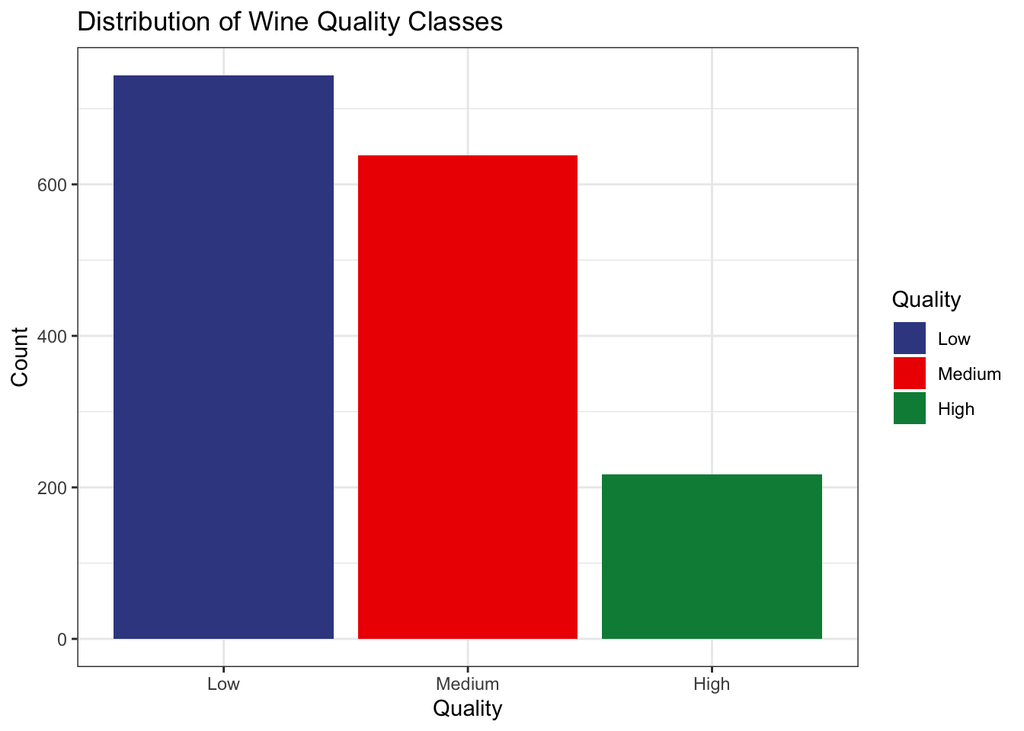

## 3. Feature Selection with LASSO

With 11 potential predictors, we can use LASSO (L1 Regularization) to automatically select the most influential variables. LASSO penalizes the magnitude of coefficients, shrinking some to exactly zero, which effectively removes them from the model. We use cross-validation to find the optimal regularization strength (`lambda`).

But first we must create our training and testing samples.

```r
### Create train and test splits ####
set.seed(42) # the answer is always 42
# creates splits while respecting distribution of the class label in both training and testing set
train_index <- createDataPartition(wine_processed$quality_factor, p = 0.75, list = FALSE)
train_data <- wine_processed[train_index, ]
train_x <- as.matrix(train_data |> dplyr::select(-quality_factor))
train_y <- train_data |> pull(quality_factor)

test_data  <- wine_processed[-train_index, ]
test_x <- as.matrix(test_data |> dplyr::select(-quality_factor))
test_y <- test_data |> pull(quality_factor)
```

```r
#### use LASSO regression on training split ####
cv_fit <- cv.glmnet(train_x, train_y, family = "multinomial", alpha = 1)
```

### Lambda vs. Deviance

The plot below shows the cross-validated deviance (a measure of error) for different values of `lambda`. The dashed vertical line indicates `lambda.min`, the value that resulted in the lowest deviance.

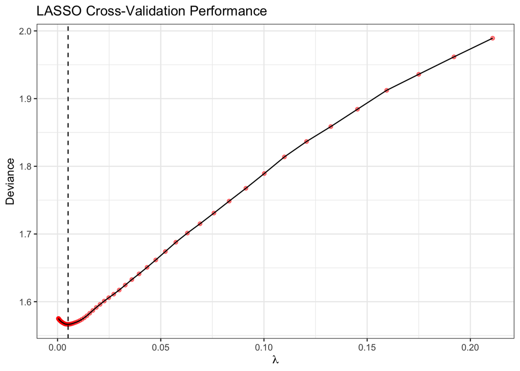

### Selected Variables

Using the optimal lambda, we inspect the model coefficients. Variables with non-zero coefficients are considered important. We can see how each variable influences the prediction for each class.

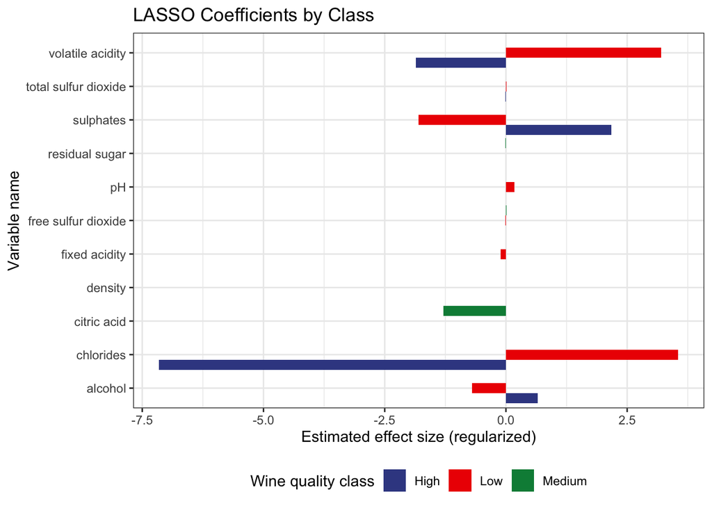

### Interpreting our LASSO results: Key Predictors by Wine Quality

Based on a threshold of `abs(value) > 0.1`, the following variables were selected for subsequent modeling:

```r
# Pulling all 'important' variables - somewhat subjective.
selected_vars <- data.frame(lasso_vars) |>
  add_column(varName = rownames(lasso_vars)) |>
  pivot_longer(cols = -varName) |>
  filter(varName != "(Intercept)") |>
  filter(value != 0) |>
  filter(abs(value) > 0.1) |>
  pull(varName) |>
  unique()
print(selected_vars)
```

```
## [1] "fixed acidity"    "volatile acidity" "citric acid"      "chlorides"
## [5] "pH"               "sulphates"        "alcohol"
```

## 4. Model Training & Comparison

We now train three classification models using only the subset of features identified by LASSO. We evaluate each model on the held-out test set (25% of the data).

### Model 1: Linear Discriminant Analysis (LDA)

LDA is a classic classifier that finds linear combinations of predictors to separate the classes.

```r
# lda
lda_model <- MASS::lda(x = train_x[,selected_vars], grouping = train_y)
lda_preds <- predict(lda_model, newdata = test_x[,selected_vars])$class
```

**Results:** The LDA model achieved an overall accuracy of **63.9%**.

```
## Confusion Matrix and Statistics
##
##           Reference
## Prediction Low Medium High
##     Low    149     58    4
##     Medium  35     82   26
##     High     2     19   24
##
## Overall Statistics
##
##                Accuracy : 0.6391
##                  95% CI : (0.5898, 0.6863)
##     No Information Rate : 0.4662
##     P-Value [Acc > NIR] : 2.808e-12
##
##                   Kappa : 0.3938
##
##  Mcnemar's Test P-Value : 0.05902
##
## Statistics by Class:
##
##                      Class: Low Class: Medium Class: High
## Sensitivity              0.8011        0.5157     0.44444
## Specificity              0.7089        0.7458     0.93913
## Pos Pred Value           0.7062        0.5734     0.53333
## Neg Pred Value           0.8032        0.6992     0.91525
## Prevalence               0.4662        0.3985     0.13534
## Detection Rate           0.3734        0.2055     0.06015
## Detection Prevalence     0.5288        0.3584     0.11278
## Balanced Accuracy        0.7550        0.6308     0.69179
```

### Model 2: Quadratic Discriminant Analysis (QDA)

QDA is a more flexible version of LDA that allows for quadratic decision boundaries.

```r
# qda
qda_model <- MASS::qda(x = train_x[,selected_vars], grouping = train_y)
qda_preds <- predict(qda_model, newdata = test_x[,selected_vars])$class
```

**Results:** The QDA model was the weakest performer, with an accuracy of **59.9%**. The additional flexibility it offers may have led to overfitting.

```
## Confusion Matrix and Statistics
##
##           Reference
## Prediction Low Medium High
##     Low    123     44    2
##     Medium  60     89   25
##     High     3     26   27
##
## Overall Statistics
##
##                Accuracy : 0.599
##                  95% CI : (0.5491, 0.6474)
##     No Information Rate : 0.4662
##     P-Value [Acc > NIR] : 6.899e-08
##
##                   Kappa : 0.3424
##
##  Mcnemar's Test P-Value : 0.4434
##
## Statistics by Class:
##
##                      Class: Low Class: Medium Class: High
## Sensitivity              0.6613        0.5597     0.50000
## Specificity              0.7840        0.6458     0.91594
## Pos Pred Value           0.7278        0.5115     0.48214
## Neg Pred Value           0.7261        0.6889     0.92128
## Prevalence               0.4662        0.3985     0.13534
## Detection Rate           0.3083        0.2231     0.06767
## Detection Prevalence     0.4236        0.4361     0.14035
## Balanced Accuracy        0.7227        0.6028     0.70797
```

### Model 3: k-Nearest Neighbors (k-NN)

k-NN is a non-parametric method that classifies a data point based on the majority class of its ‘k’ nearest neighbors. We used 10-fold cross-validation to find the optimal value for `k`.

```r
# knn
ctrl <- trainControl(method = "cv", number = 10) # 10-fold cross-validation
knn_model <- train(
  x = train_x[,selected_vars], y = train_y,
  method = "knn",
  trControl = ctrl,
  preProcess = c("center", "scale"), # Scaling is important for k-NN
  tuneGrid = expand.grid(k = seq(1, 25, by = 2)) # Try k values from 1 to 25
)
knn_preds <- predict(knn_model, newdata = test_x[,selected_vars])
```

**Results:** The k-NN model achieved an overall accuracy of **64.2%**.

```
## Confusion Matrix and Statistics
##
##           Reference
## Prediction Low Medium High
##     Low    135     42    6
##     Medium  43     94   21
##     High     8     23   27
##
## Overall Statistics
##
##                Accuracy : 0.6416
##                  95% CI : (0.5924, 0.6887)
##     No Information Rate : 0.4662
##     P-Value [Acc > NIR] : 1.366e-12
##
##                   Kappa : 0.4112
##
##  Mcnemar's Test P-Value : 0.9426
##
## Statistics by Class:
##
##                      Class: Low Class: Medium Class: High
## Sensitivity              0.7258        0.5912     0.50000
## Specificity              0.7746        0.7333     0.91014
## Pos Pred Value           0.7377        0.5949     0.46552
## Neg Pred Value           0.7639        0.7303     0.92082
## Prevalence               0.4662        0.3985     0.13534
## Detection Rate           0.3383        0.2356     0.06767
## Detection Prevalence     0.4586        0.3960     0.14536
## Balanced Accuracy        0.7502        0.6623     0.70507
```

## 5. Conclusion

**LDA** and **k-NN** are the most effective models for this classification task, with very similar performance. kNN achieved the highest overall accuracy and the highest Kappa statistic (**which indicates the best level of agreement between predictions and actuals, corrected for chance**).